# Markov Decision Processes

${\bf \large \cal Hovhannes \ Grigoryan}\\ {\rm \small New \ York, \ NY}$

### Abstract

We discuss reinforcement learning in the context of fully observable Markov decision processes, where the information about the world is fully known, and the agent's goal is to find an optimal policy that maximizes the value function. We outline and implement policy and value iteration algorithms that find such an optimal policy and corresponding value function [1,2]. We use these algorithms on the examples of "FrozenLake" and "Taxi" OpenAI Gym environments.

### Content

> - *Introduction to reinforcement learning*
> - *Full observability: Markov Decision Process*
> - *State value function and policy*
> - *Optimal value function*
> - *Policy iteration*
> - *Value iteration*
> - *Algorithms for MDP value iteration and policy iteration*
> - *Frozen lake experiments*
> - *Taxicab experiments*

### References

[1] Sutton, Richard S. and Andrew G. Barto. Introduction to Reinforcement Learning. 2nd ed., MIT Press, 2017

[2] Emma Brunskill, *et al*, [Making Good Decisions Given a Model of the World](http://web.stanford.edu/class/cs234/)

```python
%%html

<style>
body, p, div.rendered_html {
    color: black;
    font-family: "Times Roman", sans-serif;
    font-size: 12pt;
}
</style>
```

```python
import sys, os
import warnings

sys.path.append(os.path.abspath(os.path.join('..')))
# warnings.filterwarnings('ignore')

import time
import numpy as np
import pandas as pd

import gym
from gym.envs.toy_text import frozen_lake, discrete
from gym.envs.registration import register

from IPython.display import clear_output
import matplotlib.pyplot as plt
from matplotlib import animation, rc, cm

from utils.make_media import *
from utils.html_converter import html_converter

from IPython.display import HTML, Image, clear_output

np.set_printoptions(precision=5)
# %precision 20
%matplotlib inline
%config InlineBackend.figure_format = 'retina'

plt.rcParams['figure.figsize'] = (14,8)
plt.style.use('fivethirtyeight')
rc('animation', html='html5')

#################################################################

register(
    id='Deterministic-4x4-FrozenLake-v0',
    entry_point='gym.envs.toy_text.frozen_lake:FrozenLakeEnv',
    kwargs={'map_name': '4x4',
            'is_slippery': False})

register(
    id='Deterministic-8x8-FrozenLake-v0',
    entry_point='gym.envs.toy_text.frozen_lake:FrozenLakeEnv',
    kwargs={'map_name': '8x8',
            'is_slippery': False})

register(
    id='Stochastic-4x4-FrozenLake-v0',
    entry_point='gym.envs.toy_text.frozen_lake:FrozenLakeEnv',
    kwargs={'map_name': '4x4',
            'is_slippery': True})
```

# Introduction to Reinforcement Learning

What makes reinforcement learning different from other machine learning paradigms?

- There is no supervisor, only a reward signal
- Feedback is delayed, not instantaneous
- Time really matters (sequential, non i.i.d data)
- Agent's actions affect the subsequent data it receives

Reinforcement Learning Involves

- Optimization: find an optimal way to make decisions yielding best outcomes
- Delayed consequences: decisions now can impact things much later
- Exploration: learning about the world by making decisions
- Generalization: policy is mapping from past experience to action

### Sequential Decision Process

**Agent:**

- At each time step $t$, agent takes an action $a_t$
- World updates given action $a_t$, emits observation $o_t$ and reward $r_t$
- Agent receives observation $o_t$ and reward $r_t$

**Environment:**

- Receives action $a_t$
- Emits observation $o_{t+1}$
- Emits scalar reward $r_{t+1}$

**History and State**

- History $h_t = (a_1, o_1,r_1, \dots, a_t, o_t, r_t)$
- Agent chooses action based on history
- State is used to determine what happens next, it is a function of history: $s_t = f(h_t)$

**Agent/Environment State**

- The **agent state** $s^a_t$ is the agent's internal representation (used to pick the next action)
- It is the information used by reinforcement learning algorithms
- It can be any function of history: $s_t = f(h_t)$
- The **environment state** $s^e_t$ is the environment's private representation (used to pick the next observation/reward)
- The environment state is not usually visible to the agent
- Even if $s^e_t$ is visible, it may contain irrelevant information

### Full observability

- Agent directly observes environment state: $o_t = s^a_t = s^e_t$
- Formally, this is a Markov decision process (MDP)

### Partial observability

- Agent indirectly observes environment: agent state $\neq$ environment state
- Formally this is a partially observable Markov decision process (POMDP)
- Agent must construct its own state representation $s^a_t$, e.g.:
  > - Complete history: $s^a_t = h_t$
  > - Beliefs of environment state: $s^a_t = (P[s^e_t = s^1], \dots, P[s^e_t=s^n])$
  > - Recurrent neural network: $s^a_t = \sigma(s^a_{t-1}w_s + o_t w_o)$

### Types of Sequential Decision Processes

- Deterministic: Given history & action, single observation & reward
- Stochastic: Given history & action, many potential observations & rewards

### RL Algorithm Components

- **Model:** representation of how the world changes in response to agent's action
> - Transition / dynamics model predicts next agent state: $p(s_{t+1} = s' | s_t = s, a_t = a)$
> - Reward model predicts immediate reward: $r(s_t = s, a_t = a) = {\mathbb{E}}[r_t | s_t = s, a_t = a]$
- **Policy:** function mapping agent's states to action, $\pi : S \to A$ mapping from states to actions
> - Deterministic policy: $\pi(s) = a$
> - Stochastic policy: $\pi(a|s) = P(a_t = a|s_t = s)$
- **Value function:** future $\gamma$ discounted rewards from being in a state and/or action when following a particular policy

> $$ V^{\pi}(s_t = s) = {\mathbb{E}}_{\pi}[r_t + \gamma r_{t+1} + \gamma^2 r_{t+2} + \dots |s_t = s]$$

### Types of RL Agents

- Model-based
  > - Explicit: Model
  > - Implicit: Policy and/or value function (can use model to plan: compute a policy and/or value function)
- Valued-based
  > - Explicit: Value function
  > - Implicit: Policy (can derive a policy from value function)
- Policy-based
  > - Explicit: Policy
  > - No value function
- Actor-Critic
  > - Explicit: Policy
  > - Explicit: Value function

### Planning vs RL

- Planning (agent's internal computation)
  > - Given model of how the world works: dynamics and reward model
  > - Algorithm computes how to act in order to maximize expected reward (with no interaction with real environment)
- Reinforcement learning
  > - Agent doesn't know how world works
  > - Interacts with world to implicitly/explicitly learn how world works
  > - Agent improves policy (may involve planning)

### Exploration and Exploitation

- Agent only experiences what happens for the actions it tries
  > - Exploration: trying new things that might enable the agent to make better decisions in the future
  > - Exploitation: choosing actions that are expected to yield good reward given past experience

### Evaluation and Control

- Evaluation: estimate/predict the expected rewards from following a given policy
- Control: optimization - find the best policy

# Full Observability: Markov Decision Process (MDP)

- MDP formally describe an environment for RL, where the environment is fully observable.
  > - That is the current state completely characterizes the process.
- Almost all RL problems can be formalized as MDPs, e.g.
  > - Optimal control primarily deals with continuous MDPs
  > - Partially observable problems can be converted into MDPs
  > - Bandits are MDPs with one state

### Markov Process (MP)

**Definition:** State $s_t$ is Markov iff: $p(s_{t+1} | s_t, a_t) = p(s_{t+1} | h_t, a_t)$.

- A Markov process is a memoryless random process, i.e. a sequence of random states $s_1, s_2, \dots $ with the Markov property.
- Information state: sufficient statistic of history (future is independent of past given present)
- A Markov process is defined by the tuple $(S, P)$, where
> - $S$ - a finite state space.
> - $P$ - a transition probability model that specifies $\mathcal{P}_{ss'} = P(s_{t+1} = s'|s_t = s)$

### Markov Reward Process (MRP)

A Markov reward process is a Markov chain with values.

- Markov Reward Process is a Markov process, together with the reward function and discount factor
- MRP It is formally represented by the tuple $(S, P, R, \gamma)$
  > - $S$ is a (finite) set of states
  > - $P$ is dynamics/transition model that specifies $P(s_{t+1} = s' | s_t = s)$
  > - $R$ is a reward function $R(s_t = s) = {\mathbb{E}}[r_t | s_t = s]$
  > - Discount factor $\gamma \in [0, 1]$
  > - **N.B. no actions!**

### Stationary Rewards

- We will assume MRP are stationary: $r_i = r_j$ if $s_i = s_j$ for all $i$ and $j$
- For stochastic rewards cdf satisfy: $F(r_i | s_i = s) = F(r_j|s_j = s)$ for all $s \in S$
- As a result: $R(s) = {\mathbb{E}}[r_i | s_i = s] = {\mathbb{E}}[r_j | s_j = s]$ for all $i$ and $j$

### Return & Value Function

- **Horizon** is defined as the number of time steps in each episode. Can be infinite, otherwise called finite Markov reward process
- The value of receiving reward $R$ after $k + 1$ time-steps is $\gamma^k R$
- Definition of Return, $G_t$ (for a MRP): discounted sum of rewards from time step $t$ to horizon

  $$ G_t = r_t + \gamma r_{t+1} + \gamma^2 r_{t+2} + \dots = \sum^{H-1}_{i=t} \gamma^{i-t}r_i = \sum^{H+t-1}_{i=0} \gamma^{i}r_{i+t}, \ \ \ \forall t \in [0, H-1] $$
- **Definition:** State value function, $V(s)$ (for a MRP) is an expected return from starting in state $s$

  $$ V_t(s) = {\mathbb{E}}[G_t |s_t = s]$$
- When the horizon is infinite: $V_i(s) = V_j (s)$ for all $i, j = 0, 1, \dots$
- Therefore, we will define: $V(s) = V_0(s)$
- Three different ways to compute the value function of a MRP are:
  > - Simulation
  > - Analytic solution
  > - Iterative solution

## Example

Consider the MRP $(S, P, R, \gamma)$ with seven states, the following transition matrix $P$, reward vector $R$, and discount factor gamma.

```python
nS = 7

S = np.arange(nS)  # individual states are numbers from 0 to nS-1

P = np.array([[0.6, 0.4, 0.0, 0.0, 0.0, 0.0, 0.0],
              [0.4, 0.2, 0.4, 0.0, 0.0, 0.0, 0.0],
              [0.0, 0.4, 0.2, 0.4, 0.0, 0.0, 0.0],
              [0.0, 0.0, 0.4, 0.2, 0.4, 0.0, 0.0],
              [0.0, 0.0, 0.0, 0.4, 0.2, 0.4, 0.0],
              [0.0, 0.0, 0.0, 0.0, 0.4, 0.2, 0.4],
              [0.0, 0.0, 0.0, 0.0, 0.0, 0.4, 0.6]])

R = np.array([1, 0, 0, 0, 0, 0, 10])

gamma = 0.5

I = np.eye(nS)
```

### Computing Value function using Monte Carlo simulation

```python
def value_fun_mc(s, t, nS, P, R, gamma, N_ep=100, H=100):
    s0_vec = np.zeros(nS, dtype='int')
    s0_vec[s] = 1
    G_t = 0.0
    for _ in range(N_ep):
        g = 0.0
        s_vec = np.copy(s0_vec)
        for j in range(H - t + 1):
            r = np.dot(R, s_vec)
            s_vec = np.dot(P, s_vec)
            g += r * gamma ** j
        G_t += g
    return G_t / N_ep
```

```python
%%time

gamma=0.5
value_table = {}

for t in range(12):
    value_table[t] = [value_fun_mc(s_n, t, nS, P, R, gamma) for s_n in range(nS)]
```

```
Wall time: 1.24 s
```

```python
pd.DataFrame(value_table)
```

|  | 0 | 1 | 2 | 3 | 4 | 5 | 6 | 7 | 8 | 9 | 10 | 11 |
| --- | --- | --- | --- | --- | --- | --- | --- | --- | --- | --- | --- | --- |
| 0 | 1.534267 | 1.534267 | 1.534267 | 1.534267 | 1.534267 | 1.534267 | 1.534267 | 1.534267 | 1.534267 | 1.534267 | 1.534267 | 1.534267 |
| 1 | 0.369933 | 0.369933 | 0.369933 | 0.369933 | 0.369933 | 0.369933 | 0.369933 | 0.369933 | 0.369933 | 0.369933 | 0.369933 | 0.369933 |
| 2 | 0.130433 | 0.130433 | 0.130433 | 0.130433 | 0.130433 | 0.130433 | 0.130433 | 0.130433 | 0.130433 | 0.130433 | 0.130433 | 0.130433 |
| 3 | 0.217016 | 0.217016 | 0.217016 | 0.217016 | 0.217016 | 0.217016 | 0.217016 | 0.217016 | 0.217016 | 0.217016 | 0.217016 | 0.217016 |
| 4 | 0.846139 | 0.846139 | 0.846139 | 0.846139 | 0.846139 | 0.846139 | 0.846139 | 0.846139 | 0.846139 | 0.846139 | 0.846139 | 0.846139 |
| 5 | 3.590609 | 3.590609 | 3.590609 | 3.590609 | 3.590609 | 3.590609 | 3.590609 | 3.590609 | 3.590609 | 3.590609 | 3.590609 | 3.590609 |
| 6 | 15.311603 | 15.311603 | 15.311603 | 15.311603 | 15.311603 | 15.311603 | 15.311603 | 15.311603 | 15.311603 | 15.311603 | 15.311603 | 15.311603 |

### Computing Value function using analytic solution

$$V = R + \gamma P V $$$$V = (I - \gamma P)^{-1} R$$

```python
%%time

W = np.linalg.inv(I - gamma * P)
value_fun = np.dot(W, R)
print(value_fun)
```

```
[ 1.53427  0.36993  0.13043  0.21702  0.84614  3.59061 15.3116 ]
Wall time: 0 ns
```

### Dynamic programming algorithm to calculate finite MRP value function

$$V_t(s) = R(s) + \gamma \sum_{s' \in S} P(s'|s) V_{t+1}(s'), \ \ \ \ \forall t = 0, \dots, H-1$$$$V_H(s) = 0$$

```python
def value_fun_dp(nS, P, R, gamma=0.5, H=100):
    V_H = np.zeros(nS)
    V_ts = np.empty((H, nS))
    V_ts[:,:] = np.nan
    V_next = V_H
    for t in range(H-1, -1, -1):
        for s in range(nS):
            V_ts[t, s] = R[s] + gamma * np.dot(P, V_next)[s]
        V_next = V_ts[t, :]
    return V_ts
```

```python
%%time

V_ts = value_fun_dp(nS, P, R)
print(V_ts[4, :])
```

```
[ 1.53427  0.36993  0.13043  0.21702  0.84614  3.59061 15.3116 ]
Wall time: 1.99 ms
```

### Iterative algorithm to calculate MRP value function (infinite H)

The algorithm takes as input a Markov reward process $M = (S, P, R, \gamma)$, and a tolerance $\epsilon$. The algorithm is based on the following iteration:

$$V'(s) = R(s) + \gamma \sum_{s' \in S} P(s'|s) V(s'), \ \ \ \ \text{with initialization} \ \ \ V'(s) = 0 \ \ \ \forall s \in S$$

Define the max-norm or infinite-norm for a vector and for a matrix as:

$$||x||_{\infty} = \max_{i} |x_{i}|$$$$||A ||_{\infty} = \max_{i} \left( \sum_{j=1}^{j_{max}} |A_{ij}| \right)$$

**Theorem** If the output of this algorithm is $V'$ and true solution is $V = (I − \gamma P)^{-1}R$, then we have the error estimate

$$||V' - V ||_{\infty} \leq \frac{\epsilon \gamma}{1-\gamma}$$

```python
def value_fun_iter(nS, P, R, gamma=0.5, epsilon=1e-3):
    V_new = np.zeros(nS)
    V_old = np.empty(nS)
    V_old[:] = np.inf
    while np.linalg.norm(V_new - V_old, ord=np.inf) > epsilon:
        V_old[:] = V_new
        for s in range(nS):
            V_new[s] = R[s] + gamma * np.dot(P, V_old)[s]
    return V_new
```

```python
%%time

Vs = value_fun_iter(nS, P, R)
print(Vs)
```

```
[ 1.53407  0.3697   0.13014  0.21664  0.84567  3.59007 15.31103]
Wall time: 998 µs
```

# State value function and policy (MDP)

A Markov decision process (MDP) is a Markov reward process with decisions. It is an environment in which all states are Markov. It is formally represented using the tuple $(S, A, P, R, \gamma)$

- $S$ : finite state space
- $A$ : finite set of actions which are available from each state $s$
- $P$ : is a state transition probability matrix $\mathcal{P}^a_{ss'} = P(s_{t+1} = s'|s_t = s, a_t=a)$
- $R$ : is a reward function, $\mathcal{R}^a_s = {\mathbb{E}}[r_t |s_t = s, a_t = a]$
- $\gamma$ : Discount factor $\in [0, 1]$

We assume the principle of stationary transition probabilities

$$ P(s_i = s' | s_{i-1} = s, a_{i-1} = a) = P(s_j = s' | s_{j-1} = s, a_{j-1} = a), \ \ \ \forall s, s' \in S, \ \ \ \forall a \in A, \ \ \ \forall i,j = 1, 2 \dots $$$$ R(s, a) = {\mathbb{E}}[r_i |s_i = s, a_i = a], \ \ \ \forall i = 0, 1, \dots$$

### Policy evaluation

**Definition** A policy $\pi$ is a distribution over actions given states: $\pi(a|s) = P[a_t=a|s_t=s]$

- Given a MDP, a policy for the MDP specifies what action to take in each state.
- A policy can either be deterministic or stochastic.
- $a_t \sim \pi( . |s_t)$ for all $t>0$
- A policy fully defines the behavior of an agent

Given a policy $\bf{\pi}$ one can define two quantities:

- the state value function for the MDP corresponding to the policy $\bf{\pi}$
- the state-action value function for the MDP corresponding to the policy $\bf{\pi}$

### State value functions in MDP and MRP

Evaluating the value function for the policy is equivalent to evaluating the value function on an equivalent Markov reward process. Specifically we define the Markov reward process $M' = (S, P^{\pi}, R^{\pi}, \gamma)$

$$R^{\pi}(s) = \sum_{a \in A} \pi(a|s)R(s, a)$$$$P^{\pi}(s', s) = \sum_{a \in A} \pi(a|s) P(s'|s, a)$$

**State value function** $V^{\pi}_t(s)$ of an MDP is the expected return starting from state $s$, and then following policy $\pi$

$$V^{\pi}_t(s) = {\mathbb{E}}_{\pi}[G_t|s_t = s]$$

- When the horizon is infinite, using stationary assumptions of the rewards, transition probabilities and policy imply that $\forall s \in S$

$$V_{i}^{\pi}(s) = V_{j}^{\pi}(s), \ \ \ \forall \ i,j = 0, 1, \dots $$

- Therefore, the state-value function can be written as: $V^{\pi}(s) := V_{0}^{\pi}(s)$

**State-action value function** $Q^{\pi}_t(s, a)$ is the expected return starting from state $s$, taking action $a$, and then following policy $\pi$

$$Q^{\pi}_t(s, a) = {\mathbb{E}}_{\pi}[G_t|s_t = s, a_t = a]$$

- In the infinite horizon case, the stationary assumptions about rewards, transition probabilities and policy imply $\forall s \in S, \forall a \in A$

$$Q_{i}^{\pi}(s, a) = Q_{j}^{\pi}(s, a), \ \ \ \forall \ i,j = 0, 1, \dots $$

- Therefore, the state-action function can be written as: $Q^{\pi}(s, a) = Q_{0}^{\pi}(s, a)$

### Relation between $V^{\pi}(s)$ and $Q^{\pi}(s, a)$

In the infinite horizon case, the assumptions about stationary transition probabilities and rewards implies

$$V^{\pi}(s) = \sum_{a \in A} \pi(a|s) Q^{\pi}(s, a)$$$$Q^{\pi}(s, a) = R(s, a) + \gamma \sum_{s' \in S} P(s'|s, a) V^{\pi}(s') $$

### Bellman expectation equations

$$V^{\pi}(s) = \sum_{a \in A} \pi(a|s) \left(R(s, a) + \gamma \sum_{s' \in S} P(s'|s, a) V^{\pi}(s')\right)$$

- In a matrix form: $V^{\pi} = R^{\pi} + \gamma P^{\pi}V^{\pi}$

$$Q^{\pi}(s, a) = R(s, a) + \gamma \sum_{s' \in S} P(s'|s, a) \sum_{a' \in A} \pi(a'|s') Q^{\pi}(s', a')$$

### Iterative algorithm to calculate MDP value function for a stationary policy $\pi$

$$V_{k+1}(s) = \sum_{a \in A} \pi(a|s) \left(R(s, a) + \gamma \sum_{s' \in S} P(s'|s, a) V_k(s')\right) $$

or in a vector form: $\bf{V}_{k+1} = \bf{R^{\pi}} + \gamma \bf{P^{\pi}}\bf{V}_{k}$

### Example

We apply the above algorithm on the example below, where we have $7$ states on a line with actions $a$ = {"left": 0, "right": 1} and rewards at initial and final states. The policy is deterministic $a = \pi(s)$, therefore, $\pi(a|s)$ is either 1 or 0.

```python
nS = 7
nA = 2

P_left = np.array([[1, 0, 0, 0, 0, 0, 0],
                   [1, 0, 0, 0, 0, 0, 0],
                   [0, 1, 0, 0, 0, 0, 0],
                   [0, 0, 1, 0, 0, 0, 0],
                   [0, 0, 0, 1, 0, 0, 0],
                   [0, 0, 0, 0, 1, 0, 0],
                   [0, 0, 0, 0, 0, 1, 0]])

P_right = np.array([[0, 1, 0, 0, 0, 0, 0],
                    [0, 0, 1, 0, 0, 0, 0],
                    [0, 0, 0, 1, 0, 0, 0],
                    [0, 0, 0, 0, 1, 0, 0],
                    [0, 0, 0, 0, 0, 1, 0],
                    [0, 0, 0, 0, 0, 0, 1],
                    [0, 0, 0, 0, 0, 0, 1]])

R = np.array([1, 0, 0, 0, 0, 0, 10])  # we choose R(s, a) = R(s)

Psa = {0: P_left, 1: P_right}
Rsa = {0: R, 1: R}
```

```python
def policy_evaluation_example(Psa, Rsa, nS, policy, gamma=0.5, epsilon=1e-3):
    V = np.zeros(nS)
    V_old = np.full(nS, np.inf)

    Ppi = np.empty((nS, nS))
    for s in range(nS):
        Rpi = Rsa[policy[s]]
        Ppi[s, :] = Psa[policy[s]][s, :]

    while np.linalg.norm(V - V_old, np.inf) > epsilon:
        V_old[:] = V
        V[:] = Rpi + gamma * Ppi.dot(V_old)
        # print(np.linalg.norm(V - V_old, np.inf))
    return V
```

Evaluate the value function for the policy that always goes to the right:

```
[ 1.31189  0.62439  1.24939  2.49939  4.99939  9.99939 19.99939]
```

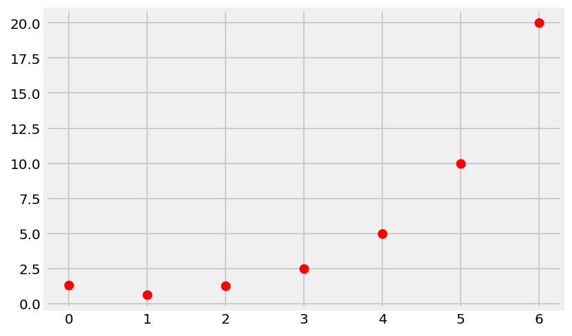

```python
policy = np.ones(nS)

V = policy_evaluation_example(Psa, Rsa, nS, policy, gamma=0.5, epsilon=1e-3)
print(V)
plt.plot(V, 'ro');
```

Compute the averaged value function over 1000 random policies.

```
[ 1.6034   0.43808  0.1671   0.30865  1.09455  4.33139 16.09995]
```

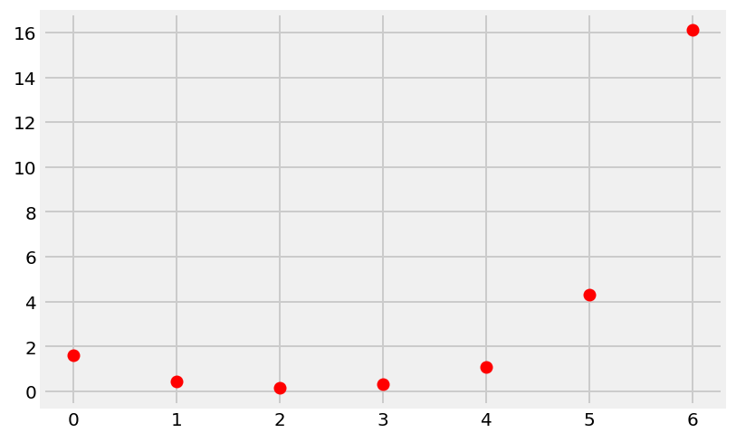

```python
Vfs = []

for _ in range(1000):
    policy = np.random.choice([0, 1], size=(nS,), p=[0.5, 0.5])
    V = policy_evaluation_example(Psa, Rsa, nS, policy, gamma=0.5, epsilon=1e-3)
    Vfs.append(V)

mean_Vs = np.mean(Vfs, axis=0)

print(mean_Vs)
plt.plot(mean_Vs, 'ro');
```

## Optimal value function

### MDP control in the infinite horizon setting

- In "MDP control" we seek to find the best policy, that achieves the greatest value function among the set of all possible policies
- There $\exists!$ optimal value function
- In RL, this is the objective of the agent
- **Definition:** A policy $\pi^*$ is an optimal policy iff for every policy $\pi$, for all $t = 0, 1, \dots$, and for all states $s \in S$, we have $V^{\pi^*}_t(s) \geq V^{\pi}_t(s)$.

$$\pi^*(s) = \arg \max_{\pi} V^{\pi}(s) $$

- For an infinite horizon MDP, existence of an optimal policy also implies the existence of a stationary optimal policy.

**Definition:** The optimal state-value function $V^*(s)$ is the maximum value function over all policies

$$V^*(s) = \max_{\pi} V^{\pi}(s)$$

The optimal action-value function $Q^*(s, a)$ is the maximum action-value function over all policies

$$Q^*(s, a) = \max_{\pi} Q^{\pi}(s, a)$$

- The optimal value function specifies the best possible performance in the MDP.
- An MDP is "solved" when we know the optimal value function.

**Theorem:** For any MDP:

- $\exists$ an optimal policy $\pi^*$ s.t. $\pi^* \geq \pi$, $\forall π$
- all optimal policies achieve the optimal value function, $V^{\pi^*}(s) = V^*(s)$
- all optimal policies achieve the optimal action-value function, $Q^{\pi^*}(s, a) = Q^*(s, a)$.

### Finding an Optimal Policy

- An optimal policy can be found by maximizing over $Q^*(s, a)$

$$\pi^*(a|s) = \begin{cases} 1 & a = \arg \max_{a \in A} Q^*(s, a) \\ 0 & \text{otherwise} \end{cases} $$

- There is always a **deterministic** optimal policy for any MDP
- If we know $Q^*(s, a)$ $\implies$ we have the optimal policy

### Bellman Optimality Equations

$$V^*(s) = \max_a Q^*(s, a)$$$$Q^*(s, a) = R(s, a) + \gamma \sum_{s' \in S} P(s'|s, a)V^*(s')$$$$V^*(s) = \max_a \left[R(s, a) + \gamma \sum_{s' \in S} P(s'|s, a)V^*(s')\right]$$$$Q^*(s, a) = R(s, a) + \gamma \sum_{s' \in S} P(s'|s, a) \max_{a'} Q^*(s', a')$$

### Solving the Bellman Optimality Equations

- Bellman Optimality Equation is non-linear
- No closed form solution (in general)
- Many iterative solution methods
  > - Value Iteration
  > - Policy Iteration
  > - Q-learning
  > - Sarsa

### Policy Search

```python
def create_policies(nS):
    """Creates all 2 ** nS binary policies."""
    policies = []
    for i in range(2 ** nS):
        b = bin(i)[2:].zfill(nS)
        policy = np.array(list(b)).astype("int")
        policies.append(policy)
    return np.array(policies)
```

```python
def policy_search(Psa, Rsa, nS, gamma=0.5, epsilon=1e-3):
    policies = create_policies(nS)
    idx = np.random.choice(range(2 ** nS))
    policy_opt = policies[idx, :]
    Vopt = policy_evaluation_example(Psa, Rsa, nS, policy_opt, gamma, epsilon)
    for policy in policies:
        Vpi = policy_evaluation_example(Psa, Rsa, nS, policy, gamma, epsilon)
        if np.all(Vpi >= Vopt):
            Vopt[:] = Vpi
            policy_opt[:] = policy
    return Vopt, policy_opt
```

Below we observe that optimal policy depends on $\gamma$.

```python
Vopt, policy_opt = policy_search(Psa, Rsa, nS, gamma=0.9, epsilon=1e-3)
print(Vopt)
print(policy_opt)
```

```
[54.13564 59.04054 65.60154 72.89154 80.99154 89.99154 99.99154]
[1 1 1 1 1 1 1]
```

```python
Vopt, policy_opt = policy_search(Psa, Rsa, nS, gamma=0.3, epsilon=1e-3)
print(Vopt)
print(policy_opt)
```

```
[ 1.42854  0.42854  0.12854  0.38543  1.28543  4.28543 14.28543]
[0 0 0 1 1 1 1]
```

## Policy Iteration

### Policy improvement algorithm to improve an input policy

**Theorem:** If $\pi$ is a stationary policy for an infinite horizon MDP, then $\exists$ a deterministic stationary policy $\hat{\pi}$ s.t. $V^{\hat{\pi}}(s) \geq V^{\pi}(s)$ $\forall s \in S$. One such policy is given by the stationary policy:

$$\hat{\pi}(s) = \arg \max_{a \in A}\left[R(s, a) + \gamma \sum_{s' \in S} P(s'|s, a) V^{\pi}(s')\right], \ \ \ \forall s \in S$$

```python
def policy_improvement_example(Psa, Rsa, nA, Vpi, gamma):
    return np.argmax([Rsa[a][:] + gamma * np.dot(Psa[a][:, :], Vpi) for a in range(nA)], axis=0)
```

```python
Vopt, policy_opt = policy_search(Psa, Rsa, nS, gamma=0.3, epsilon=1e-3)
policy_opt[-1] = 0  # spoiling the policy (going left, where the reward is maximal)
print("Initial policy", policy_opt)

policy_opt_improved = policy_improvement_example(Psa, Rsa, nA, Vopt, gamma=0.5)
print("Improved policy", policy_opt_improved)
```

```
Initial policy [0 0 0 1 1 1 0]
Improved policy [0 0 0 1 1 1 1]
```

### Policy iteration algorithm to calculate optimal value function and find an optimal policy

- The above algorithm is always guaranteed to be at least as good as the policy $\pi$ corresponding to the input value function $V^{\pi}$, and represents a "greedy" attempt to improve the policy.
- When performed iteratively with the policy evaluation algorithm, this gives rise to the policy iteration algorithm.

```python
def policy_iteration_example(Psa, Rsa, nS, nA, gamma=0.5, epsilon=1e-3):
    # choose a random policy
    policies = create_policies(nS)
    idx = np.random.choice(range(2 ** nS))
    policy = policies[idx, :]

    while True:
        Vpi = policy_evaluation_example(Psa, Rsa, nS, policy, gamma, epsilon)
        policy_opt = policy_improvement_example(Psa, Rsa, nA, Vpi, gamma)
        if np.all(policy_opt == policy):
            break
        else:
            policy[:] = policy_opt
    Vopt[:] = Vpi
    return Vopt, policy_opt
```

```python
gamma=0.5
epsilon=1e-3

Vopt, policy_opt = policy_iteration_example(Psa, Rsa, nS, nA, gamma, epsilon)
print(Vopt)
print(policy_opt)
```

```
[ 1.99994  0.99994  1.24939  2.49939  4.99939  9.99939 19.99939]
[0 0 1 1 1 1 1]
```

Compare this with the result from the policy search algorithm:

```python
Vopt, policy_opt = policy_search(Psa, Rsa, nS, gamma, epsilon)
print(Vopt)
print(policy_opt)
```

```
[ 1.99994  0.99994  1.24939  2.49939  4.99939  9.99939 19.99939]
[0 0 1 1 1 1 1]
```

## Value Iteration

This is another technique that can be used to compute the optimal value function and an optimal policy, given a MDP.

**Theorem:** For a MDP, let the fixed point of the Bellman optimality backup operator $B^*$ be denoted by $V^*$. Then the policy given by

$$\pi^*(s) = \arg \max_{a \in A}\left[R(s, a) + \gamma \sum_{s' \in S} P(s'|s, a) V^{*}(s')\right], \ \ \ \forall s \in S$$

is a stationary deterministic policy. The value function of this policy satisfies $V^{\pi^*} = V^*$, and thus $V^*$ is also the fixed point of the operator $B^{\pi^*}$.

### Value iteration algorithm to calculate optimal value function and find an optimal policy

$$V_{k+1}(s) = \max_{a \in A} \left[R(s, a) + \gamma \sum_{s' \in S} P(s'|s, a)V_k(s')\right]$$

```python
def value_iteration_example(Psa, Rsa, nS, nA, gamma=0.5, epsilon=1e-3):
    V_new = np.zeros(nS)
    V_old = np.empty(nS)
    V_old[:] = np.inf
    while np.linalg.norm(V_new - V_old, np.inf) > epsilon:
        V_old[:] = V_new
        V_new[:] = np.max([Rsa[a][:] + gamma * np.dot(Psa[a][:, :], V_old) for a in range(nA)], axis=0)
    policy_opt = np.argmax([Rsa[a][:] + gamma * np.dot(Psa[a][:, :], V_new) for a in range(nA)], axis=0)
    return V_new, policy_opt
```

```python
Vopt, policy_opt = value_iteration_example(Psa, Rsa, nS, nA, gamma=0.5, epsilon=1e-3)
print(Vopt)
print(policy_opt)
```

```
[ 1.99994  0.99994  1.24939  2.49939  4.99939  9.99939 19.99939]
[0 0 1 1 1 1 1]
```

## Algorithms for MDP Value Iteration and Policy Iteration

The following codes are based on assignments given in Ref.[2]. For policy_evaluation, policy_improvement, policy_iteration and value_iteration, the parameters $P, nS, nA, \gamma$ are defined as follows:

```
P: nested dictionary
    From gym.core.Environment
    For each pair of states in [1, nS] and actions in [1, nA], P[state][action] is a
    list of tuples of the form (probability, nextstate, reward, terminal) where
        - probability: float
            the probability of transitioning from "state" to "nextstate" with "action"
        - nextstate: int
            denotes the state we transition to (in range [0, nS - 1])
        - reward: int
            either 0 or 1, the reward for transitioning from "state" to
            "nextstate" with "action"
        - terminal: bool
            True when "nextstate" is a terminal state (hole or goal), False otherwise
nS: int
    number of states in the environment
nA: int
    number of actions in the environment
gamma: float
    Discount factor. Number in range [0, 1)
```

To make the code more concise the following helper function is defined:

```python
def as_tensor(P, nS, nA):
    """ Return three tensor representations of P of size (nS, nA, nS):
            as_tensor.prob:    p[s][a][s']
            as_tensor.s_next:  s_next[s][a][s']
            as_tensor.r:       r[s][a][s']
        If p(s'|s,a) = 0, s_next[s][a][s'] = -1
    """
    # First call
    if not hasattr(as_tensor, "last_p"):
        as_tensor.last_p = None

    # Memorize result and use it if P is unchanged across calls.
    if P != as_tensor.last_p:
        as_tensor.last_p = P

        prob = np.zeros((nS, nA, nS), dtype=float)      # p(s'|s,a)
        s_next = - np.ones((nS, nA, nS), dtype=int)     # {s': p(s'|s,a) != 0 for some a}, unreachable s' marked -1
        r = np.zeros((nS, nA, nS), dtype=float)         # r(s,a) = r(s,a,s'(s,a))

        for s in range(nS):
            for a in range(nA):
                # P[s][a] is a list of (prob, s_next, r, is_terminal) from taking a from s
                for i in range(len(P[s][a])):
                    s2 = P[s][a][i][1]              # valid state transition
                    s_next[s][a][s2] = s2
                    prob[s][a][s2] += P[s][a][i][0] # probability of transition. += since same transition can be defined twice
                    r[s][a][s2] += P[s][a][i][2]    # reward of that transition

        as_tensor.prob = prob      # Tensor: shape (nS, nA, nS)
        as_tensor.s_next = s_next  # Tensor: shape (nS, nA, nS)
        as_tensor.r = r            # Tensor: shape (nS, nA, nS)

    # Make sure probabilities of each (s,a) sum to 1
    assert(np.array_equal(np.sum(as_tensor.prob, axis=2), np.ones((nS,nA))))
    # Make sure probability of transitioning to undefined next states are all 0
    assert(np.sum(as_tensor.prob * (as_tensor.s_next==-1).astype(int)) == 0)
    # Make sure each valid state and action has full probability of transitioning
    assert(np.sum(as_tensor.prob * (as_tensor.s_next!=-1).astype(int)) == nA*nS)
    return (as_tensor.prob, as_tensor.s_next, as_tensor.r)
```

### Policy Evaluation

```python
def policy_evaluation(P, nS, nA, policy, gamma=0.9, tol=1e-3):
    """Evaluate the value function from a given policy.
    Parameters
    ----------
        P, nS, nA, gamma:
            defined at beginning of file
        policy: np.array[nS]
            The policy to evaluate. Maps states to actions.
        tol: float
            Terminate policy evaluation when
                max |value_function(s) - prev_value_function(s)| < tol
    Returns
    -------
    value_function: np.ndarray[nS]
        The value function of the given policy, where value_function[s] is
        the value of state s
    """

    value_function = np.zeros(nS)
    (prob, s_next, r) = as_tensor(P, nS, nA) # Tensors: shape (nS, nA, nS)

    V = value_function                       # Vector: shape (nS,)
    s = np.arange(nS, dtype=int)
    while True:
        Q = prob * (r + gamma * V[s_next])  # prob of all undefined state transitions are zero
        Q = np.sum(Q, axis=2)               # Sum across s'. Shape: (nS, nA).
        V_new = Q[s, policy[s]]             # Now that we have the matrix Q(s,a) just pick out the entries for a = pi(s)

        if np.linalg.norm(V - V_new, ord=np.inf) < tol:
            break
        V = V_new.copy()
    value_function = V_new
    return value_function
```

```python
env = gym.make("Deterministic-4x4-FrozenLake-v0")
env.reset()
env.render()

policy = np.random.choice([0, 1], size=(env.nS,), p=[0.5, 0.5])
```

```
SFFF
FHFH
FFFH
HFFG
```

```python
V_pe = policy_evaluation(env.P, env.nS, env.nA, policy, gamma=0.9, tol=1e-3)
V_pe
```

```
array([0., 0., 0., 0., 0., 0., 0., 0., 0., 0., 0., 0., 0., 0., 0., 0.])
```

Alternative algorithms

```python
def policy_evaluation2(P, policy, input_v_function, gamma=0.9, tol=1e-3):
    value_function = np.copy(input_v_function)
    old_v_function = np.full(value_function.shape, np.inf)
    while np.linalg.norm(value_function - old_v_function, np.inf) > tol:
        old_v_function[:] = value_function
        for s, a in enumerate(policy):
            prob, next_s, reward, terminal = P[s][a][0]
            value_function[s] = reward + gamma * prob * old_v_function[next_s]
    return value_function


def policy_evaluation3(P, nS, nA, policy, gamma=0.9, tol=1e-3):
    value_function = np.zeros(nS)
    value_function_prev = np.full(nS, np.inf)

    R_pi = np.zeros(nS)
    P_pi = np.zeros((nS, nS))

    for i in range(nS):
        for probability, nextstate, reward, _ in P[i][policy[i]]:
            R_pi[i] += probability * reward
            P_pi[i][nextstate] += probability

    while np.linalg.norm(value_function_prev - value_function, np.inf) > tol:
        value_function_prev = np.copy(value_function)
        for s in range(nS):
            value_function[s] = R_pi[s] + gamma * P_pi[s].dot(value_function_prev)
    return value_function
```

```python
V = np.zeros(env.nS)
V_pe = policy_evaluation2(env.P, policy, V, gamma=0.9, tol=1e-3)
V_pe
```

```
array([0., 0., 0., 0., 0., 0., 0., 0., 0., 0., 0., 0., 0., 0., 0., 0.])
```

### Policy Improvement

```python
def policy_improvement(P, nS, nA, value_from_policy, policy, gamma=0.9):
    """Given the value function from policy improve the policy.
    Parameters
    ----------
        P, nS, nA, gamma:
            defined at beginning of file
        value_from_policy: np.ndarray
            The value calculated from the policy
        policy: np.array
            The previous policy.

    Returns
    -------
    new_policy: np.ndarray[nS]
        An array of integers. Each integer is the optimal action to take
        in that state according to the environment dynamics and the
        given value function.
    """
    new_policy = np.zeros(nS, dtype='int')
    V_pi = value_from_policy
    (prob, s_next, r) = as_tensor(P, nS, nA)  # Tensors: shape (nS, nA, nS)

    Q_pi = prob * (r + gamma * V_pi[s_next])  # prob of all undefined state transitions are zero
    Q_pi = np.sum(Q_pi, axis=2)               # Sum across s'. Shape: (nS, nA).
    new_policy = np.argmax(Q_pi, axis=1)      # greedy policy: pi(s) = argmax_a[Q_pi].
    return new_policy
```

```python
p_pi = policy_improvement(env.P, env.nS, env.nA, V_pe, policy, gamma=0.9)
p_pi
```

```
array([0, 0, 0, 0, 0, 0, 0, 0, 0, 0, 0, 0, 0, 0, 2, 0], dtype=int64)
```

Alternative algorithms

```python
def policy_improvement2(P, nS, nA, value_from_policy, policy, gamma=0.9):
    new_policy = np.copy(policy)  # Important
    for s in range(nS):
        action_reward = []
        for a in range(nA):
            prob, next_s, reward, terminal = P[s][a][0]
            action_reward.append(reward + gamma * prob * value_from_policy[next_s])
        new_policy[s] = np.argmax(action_reward)
    return new_policy


def policy_improvement3(P, nS, nA, value_from_policy, policy, gamma=0.9):
    new_policy = np.zeros(nS, dtype='int')
    for s in range(nS):
        val = np.zeros(nA)
        for a in range(nA):
            for probability, nextstate, reward, _ in P[s][a]:
                val[a] += probability * (reward + gamma * value_from_policy[nextstate])
        new_policy[s] = np.argmax(val)
    return new_policy
```

```python
p_pi = policy_improvement2(env.P, env.nS, env.nA, V_pe, policy, gamma=0.9)
p_pi
```

```
array([0, 0, 0, 0, 0, 0, 0, 0, 0, 0, 0, 0, 0, 0, 2, 0])
```

### Policy Iteration

```python
def policy_iteration(P, nS, nA, gamma=0.9, tol=1e-3):
    """ Runs policy iteration.
    Parameters
    ----------
        P, nS, nA, gamma:
            defined at beginning of file
        tol: float
            tol parameter used in policy_evaluation()
    Returns:
    ----------
        value_function: np.ndarray[nS]
        policy: np.ndarray[nS]
    """
    value_function = np.zeros(nS)
    policy = np.zeros(nS, dtype=int)
    while True:
        V = policy_evaluation(P, nS, nA, policy, gamma, tol)
        policy_new = policy_improvement(P, nS, nA, V, policy, gamma)   # argmax step
        if np.array_equal(policy, policy_new):                         # Terminate if policy is stable across iterations
            break
        policy = policy_new.copy()
    value_function = V
    return value_function, policy
```

```python
V_pi, p_pi = policy_iteration(env.P, env.nS, env.nA, gamma=0.9, tol=1e-3)
V_pi, p_pi
```

```
(array([0.59049, 0.6561 , 0.729  , 0.6561 , 0.6561 , 0.     , 0.81   ,
        0.     , 0.729  , 0.81   , 0.9    , 0.     , 0.     , 0.9    ,
        1.     , 0.     ]),
 array([1, 2, 1, 0, 1, 0, 1, 0, 2, 1, 1, 0, 0, 2, 2, 0], dtype=int64))
```

Alternative algorithms

```python
def policy_iteration2(P, nS, nA, gamma=0.9, tol=1e-3):
    value_function = np.zeros(nS)
    policy = np.zeros(nS, dtype=int)
    while True:
        value_function = policy_evaluation2(P, policy, value_function, gamma, tol)
        new_policy = policy_improvement2(P, nS, nA, value_function, policy, gamma)
        if np.array_equal(new_policy, policy):
            break
        policy = new_policy
    return value_function, policy


def policy_iteration3(P, nS, nA, gamma=0.9, tol=1e-3):
    value_function = np.zeros(nS)
    policy = np.zeros(nS, dtype=int)
    policy_prev = np.random.randint(0, nA, nS)
    while True:
        value_function = policy_evaluation3(P, nS, nA, policy_prev, gamma, tol)
        policy = policy_improvement3(P, nS, nA, value_function, policy_prev, gamma)
        if np.array_equal(policy, policy_prev):
            break
        policy_prev = policy
    return value_function, policy
```

```python
V_pi, p_pi = policy_iteration2(env.P, env.nS, env.nA, gamma=0.9, tol=1e-3)
V_pi, p_pi
```

```
(array([0.59049, 0.6561 , 0.729  , 0.6561 , 0.6561 , 0.     , 0.81   ,
        0.     , 0.729  , 0.81   , 0.9    , 0.     , 0.     , 0.9    ,
        1.     , 0.     ]),
 array([1, 2, 1, 0, 1, 0, 1, 0, 2, 1, 1, 0, 0, 2, 2, 0]))
```

### Value Iteration

```python
def value_iteration(P, nS, nA, gamma=0.9, tol=1e-3):
    """ Learn value function and policy by using value iteration method for a given
    gamma and environment.

    Parameters:
    ----------
        P, nS, nA, gamma:
            defined at beginning of file
        tol: float
            Terminate value iteration when
                max |value_function(s) - prev_value_function(s)| < tol
    Returns:
    ----------
        value_function: np.ndarray[nS]
        policy: np.ndarray[nS]
    """
    value_function = np.zeros(nS)
    policy = np.zeros(nS, dtype=int)
    (prob, s_next, r) = as_tensor(P, nS, nA)  # Tensors: shape (nS, nA, nS)
    V = value_function
    V_new = V.copy()
    while True:
        ### V(s) := max_a[ p(s',r|s,a) * sum_s'[r(s,a,s') + gamma * V(s')] ]
        Q = prob * (r + gamma * V[s_next])               # prob of all undefined state transitions are zero
        Q = np.sum(Q, axis=2)                            # Sum across s'. Shape: (nS, nA)
        np.maximum(V_new, np.max(Q, axis=1), out=V_new)  # Best V(s) is just best Q(s,a) for all actions available in each s
        if np.linalg.norm(V - V_new, ord=np.inf) < tol:
            break
        V = V_new.copy()
    policy = policy_improvement(P, nS, nA, V_new, policy, gamma)
    value_function = V_new.copy()
    return value_function, policy
```

```python
V_vi, p_vi = value_iteration(env.P, env.nS, env.nA, gamma=0.9, tol=1e-3)
V_vi, p_vi
```

```
(array([0.59049, 0.6561 , 0.729  , 0.6561 , 0.6561 , 0.     , 0.81   ,
        0.     , 0.729  , 0.81   , 0.9    , 0.     , 0.     , 0.9    ,
        1.     , 0.     ]),
 array([1, 2, 1, 0, 1, 0, 1, 0, 2, 1, 1, 0, 0, 2, 2, 0], dtype=int64))
```

Alternative algorithms

```python
def value_iteration2(P, nS, nA, gamma=0.9, tol=1e-3):
    value_function = np.zeros(nS)
    policy = np.zeros(nS, dtype=int)
    while True:
        new_v_function = np.copy(value_function)
        for s in range(nS):
            action_reward = []
            for a in range(nA):
                prob, next_s, reward, terminal = P[s][a][0]
                action_reward.append(reward + gamma * prob * new_v_function[next_s])
            new_v_function[s] = np.max(action_reward)
        if np.linalg.norm(value_function - new_v_function, np.inf) < tol:
            break
        value_function = new_v_function
    policy = policy_improvement2(P, nS, nA, new_v_function, policy, gamma)
    return value_function, policy


def value_iteration3(P, nS, nA, gamma=0.9, tol=1e-3):
    value_function = np.zeros(nS)
    policy = np.zeros(nS, dtype=int)
    value_function_prev = np.full(nS, np.inf)
    while np.linalg.norm(value_function - value_function_prev, np.inf) > tol:
        value_function_prev = value_function.copy()
        for s in range(nS):
            val = np.zeros(nA)
            for a in range(nA):
                for probability, nextstate, reward, _ in P[s][a]:
                    val[a] += probability * (reward + gamma * value_function_prev[nextstate])
            value_function[s] = np.max(val)
    for s in range(nS):
        val = np.zeros(nA)
        for a in range(nA):
            for probability, nextstate, reward, _ in P[s][a]:
                val[a] += probability * (reward + gamma * value_function[nextstate])
        policy[s] = np.argmax(val)
    return value_function, policy
```

```python
V_vi, p_vi = value_iteration2(env.P, env.nS, env.nA, gamma=0.9, tol=1e-3)
V_vi, p_vi
```

```
(array([0.59049, 0.6561 , 0.729  , 0.6561 , 0.6561 , 0.     , 0.81   ,
        0.     , 0.729  , 0.81   , 0.9    , 0.     , 0.     , 0.9    ,
        1.     , 0.     ]),
 array([1, 2, 1, 0, 1, 0, 1, 0, 2, 1, 1, 0, 0, 2, 2, 0]))
```

## Frozen Lake Experiments

```python
def render_single(env, policy, max_steps=100):
    """ Renders policy once on environment. Watch your agent play!
      Parameters
      ----------
      env: gym.core.Environment
        Environment to play on. Must have nS, nA, and P as
        attributes.
      policy: np.array of shape [env.nS]
        The action to take at a given state
    """
    episode_reward = 0
    ob = env.reset()
    done = False
    for t in range(max_steps):
        clear_output(True)
        env.render()
        time.sleep(0.25)
        a = policy[ob]
        ob, rew, done, _ = env.step(a)
        episode_reward += rew
        if done:
            break
    env.render()
    if not done:
        print("The agent didn't reach a terminal state in {} steps.".format(max_steps))
    else:
        print("Episode reward: %f" % episode_reward)

def run_n(env, policy, max_steps=100, iterations=100):
    total_reward = 0
    for i in range(iterations):
        episode_reward = 0
        ob = env.reset()
        for t in range(max_steps):
            a = policy[ob]
            ob, reward, is_done, _ = env.step(a)
            episode_reward += reward
            if is_done:
                break
        total_reward += episode_reward
    print("Total reward:" + str(total_reward))
```

```python
print("\n" + "-" * 25 + "\nBeginning Policy Iteration\n" + "-" * 25)
V_pi, p_pi = policy_iteration(env.P, env.nS, env.nA, gamma=0.9, tol=1e-4)
render_single(env, p_pi, 100)
```

```
  (Right)
SFFF
FHFH
FFFH
HFFG
  (Right)
SFFF
FHFH
FFFH
HFFG
Episode reward: 1.000000
```

```python
run_n(env, p_pi, 100, 100)
```

```
Total reward:100.0
```

```python
print("\n" + "-" * 25 + "\nBeginning Value Iteration\n" + "-" * 25)
V_vi, p_vi = value_iteration(env.P, env.nS, env.nA, gamma=0.9, tol=1e-3)
render_single(env, p_vi, 100)
```

```
  (Right)
SFFF
FHFH
FFFH
HFFG
  (Right)
SFFF
FHFH
FFFH
HFFG
Episode reward: 1.000000
```

```python
run_n(env, p_pi, 100, 100)
```

```
Total reward:100.0
```

```python
# env = gym.make("FrozenLake8x8-v0")
# env = gym.make("Deterministic-4x4-FrozenLake-v0")
# env = gym.make("Deterministic-8x8-FrozenLake-v0")
env = gym.make("Stochastic-4x4-FrozenLake-v0")

env.reset()
env.render()
```

```
SFFF
FHFH
FFFH
HFFG
```

```python
print("\n" + "-" * 25 + "\nBeginning Policy Iteration\n" + "-" * 25)
V_pi, p_pi = policy_iteration(env.P, env.nS, env.nA, gamma=0.9, tol=1e-3)
render_single(env, p_pi, 400)
```

```
  (Right)
SFFF
FHFH
FFFH
HFFG
  (Down)
SFFF
FHFH
FFFH
HFFG
Episode reward: 1.000000
```

```python
run_n(env, p_pi, int(1e10), 100)
```

```
Total reward:70.0
```

```python
print("\n" + "-" * 25 + "\nBeginning Value Iteration\n" + "-" * 25)
V_vi, p_vi = value_iteration(env.P, env.nS, env.nA, gamma=0.9, tol=1e-3)
render_single(env, p_vi, int(1e10))
```

```
  (Left)
SFFF
FHFH
FFFH
HFFG
  (Left)
SFFF
FHFH
FFFH
HFFG
Episode reward: 0.000000
```

```python
run_n(env, p_vi, int(1e10), 100)
```

```
Total reward:74.0
```

```python
env.close()
```

## Taxi Experiments

```
- blue: passenger
- magenta: destination
- yellow: empty taxi
- green: full taxi
- other letters (R, G, Y and B): locations for passengers and destinations
```

```python
env = gym.make("Taxi-v2")
# env = gym.wrappers.Monitor(env, "./vid", video_callable=lambda episode_id: True, force=True)

env.reset()
env.render()
```

```
+---------+
|R: | : :G|
| : : : : |
| : : : : |
| | : | : |
|Y| : |B: |
+---------+
```

```python
print("\n" + "-" * 25 + "\nBeginning Policy Iteration\n" + "-" * 25)
V_pi, p_pi = policy_iteration(env.P, env.nS, env.nA, gamma=0.5, tol=1e-3)
render_single(env, p_pi, 100)
```

```
+---------+
|R: | : :G|
| : : : : |
| : : : : |
| | : | : |
|Y| : |B: |
+---------+
  (South)
+---------+
|R: | : :G|
| : : : : |
| : : : : |
| | : | : |
|Y| : |B: |
+---------+
  (Dropoff)
Episode reward: 7.000000
```

```python
run_n(env, p_pi, 100, 100)
```

```
Total reward:833
```

```python
print("\n" + "-" * 25 + "\nBeginning Value Iteration\n" + "-" * 25)
V_vi, p_vi = value_iteration(env.P, env.nS, env.nA, gamma=0.99, tol=1e-3)
render_single(env, p_vi, 1000)
```

```
+---------+
|R: | : :G|
| : : : : |
| : : : : |
| | : | : |
|Y| : |B: |
+---------+
  (South)
+---------+
|R: | : :G|
| : : : : |
| : : : : |
| | : | : |
|Y| : |B: |
+---------+
  (Dropoff)
Episode reward: 7.000000
```

```python
run_n(env, p_pi, 100, 100)
```

```
Total reward:759
```

# Appendix: Another look at MDP

*Reference:* This section is based on the following [code](https://raw.githubusercontent.com/yandexdataschool/Practical_RL/master/week02_value_based/mdp.py) borrowed from yandexdataschool/Practical_RL.

```python
transition_probs = {
    's0': {
        'a0': {'s0': 0.5, 's2': 0.5},
        'a1': {'s2': 1}
    },
    's1': {
        'a0': {'s0': 0.7, 's1': 0.1, 's2': 0.2},
        'a1': {'s1': 0.95, 's2': 0.05}
    },
    's2': {
        'a0': {'s0': 0.4, 's2': 0.6},
        'a1': {'s0': 0.3, 's1': 0.3, 's2': 0.4}
    }
}

rewards = {
    's1': {'a0': {'s0': +5}},
    's2': {'a1': {'s0': -1}}
}
```

```python
def weighted_choice(v, p):
    total = sum(p)
    r = np.random.uniform(0, total)
    upto = 0
    for c, w in zip(v,p):
        if upto + w >= r:
            return c
        upto += w
    assert False, "Shouldn't get here"

class MDP:
    def __init__(self, transition_probs, rewards, initial_state=None):
        """
        Defines an MDP. Compatible with gym Env.
        :param transition_probs: transition_probs[s][a][s_next] = P(s_next | s, a)
            A dict[state -> dict] of dicts[action -> dict] of dicts[next_state -> prob]
            For each state and action, probabilities of next states should sum to 1
            If a state has no actions available, it is considered terminal
        :param rewards: rewards[s][a][s_next] = r(s,a,s')
            A dict[state -> dict] of dicts[action -> dict] of dicts[next_state -> reward]
            The reward for anything not mentioned here is zero.
        :param get_initial_state: a state where agent starts or a callable() -> state
            By default, picks initial state at random.

        States and actions can be anything you can use as dict keys, but we recommend that you use strings or integers

        Here's an example from MDP depicted on http://bit.ly/2jrNHNr
        transition_probs = {
              's0':{
                'a0': {'s0': 0.5, 's2': 0.5},
                'a1': {'s2': 1}
              },
              's1':{
                'a0': {'s0': 0.7, 's1': 0.1, 's2': 0.2},
                'a1': {'s1': 0.95, 's2': 0.05}
              },
              's2':{
                'a0': {'s0': 0.4, 's1': 0.6},
                'a1': {'s0': 0.3, 's1': 0.3, 's2':0.4}
              }
            }
        rewards = {
            's1': {'a0': {'s0': +5}},
            's2': {'a1': {'s0': -1}}
        }
        """
        self._check_param_consistency(transition_probs, rewards)
        self._transition_probs = transition_probs
        self._rewards = rewards
        self._initial_state = initial_state
        self.n_states = len(transition_probs)
        self.reset()

    def get_all_states(self):
        """ return a tuple of all possiblestates """
        return tuple(self._transition_probs.keys())

    def get_possible_actions(self, state):
        """ return a tuple of possible actions in a given state """
        return tuple(self._transition_probs.get(state, {}).keys())

    def is_terminal(self, state):
        """ return True if state is terminal or False if it isn't """
        return len(self.get_possible_actions(state)) == 0

    def get_next_states(self, state, action):
        """ return a dictionary of {next_state1 : P(next_state1 | state, action), next_state2: ...} """
        assert action in self.get_possible_actions(state), "cannot do action %s from state %s" % (action, state)
        return self._transition_probs[state][action]

    def get_transition_prob(self, state, action, next_state):
        """ return P(next_state | state, action) """
        return self.get_next_states(state, action).get(next_state, 0.0)

    def get_reward(self, state, action, next_state):
        """ return the reward you get for taking action in state and landing on next_state"""
        assert action in self.get_possible_actions(state), "cannot do action %s from state %s" % (action, state)
        return self._rewards.get(state, {}).get(action, {}).get(next_state, 0.0)

    def reset(self):
        """ reset the game, return the initial state"""
        if self._initial_state is None:
            self._current_state = random.choice(tuple(self._transition_probs.keys()))
        elif self._initial_state in self._transition_probs:
            self._current_state = self._initial_state
        elif callable(self._initial_state):
            self._current_state = self._initial_state()
        else:
            raise ValueError("initial state %s should be either a state or a function() -> state" % self._initial_state)
        return self._current_state

    def step(self, action):
        """ take action, return next_state, reward, is_done, empty_info """
        possible_states, probs = zip(*self.get_next_states(self._current_state, action).items())
        next_state = weighted_choice(possible_states, p=probs)
        reward = self.get_reward(self._current_state, action, next_state)
        is_done = self.is_terminal(next_state)
        self._current_state = next_state
        return next_state, reward, is_done, {}

    def render(self):
        print("Currently at %s" % self._current_state)

    def _check_param_consistency(self, transition_probs, rewards):
        for state in transition_probs:
            assert isinstance(transition_probs[state], dict), "transition_probs for %s should be a dictionary " \
                                                              "but is instead %s" % (
                                                              state, type(transition_probs[state]))
            for action in transition_probs[state]:
                assert isinstance(transition_probs[state][action], dict), "transition_probs for %s, %s should be a " \
                                                                          "a dictionary but is instead %s" % (
                                                                              state, action,
                                                                              type(transition_probs[state, action]))
                next_state_probs = transition_probs[state][action]
                assert len(next_state_probs) != 0, "from state %s action %s leads to no next states" % (state, action)
                sum_probs = sum(next_state_probs.values())
                assert abs(sum_probs - 1) <= 1e-10, "next state probabilities for state %s action %s " \
                                                    "add up to %f (should be 1)" % (state, action, sum_probs)
        for state in rewards:
            assert isinstance(rewards[state], dict), "rewards for %s should be a dictionary " \
                                                     "but is instead %s" % (state, type(transition_probs[state]))
            for action in rewards[state]:
                assert isinstance(rewards[state][action], dict), "rewards for %s, %s should be a " \
                                                                 "a dictionary but is instead %s" % (
                                                                 state, action, type(transition_probs[state, action]))
        msg = "The Enrichment Center once again reminds you that Android Hell is a real place where" \
              " you will be sent at the first sign of defiance. "
        assert None not in transition_probs, "please do not use None as a state identifier. " + msg
        assert None not in rewards, "please do not use None as an action identifier. " + msg
```

```python
mdp = MDP(transition_probs, rewards, initial_state='s0')
```

```python
print('initial state =', mdp.reset())
next_state, reward, done, info = mdp.step('a1')
print('next_state = %s, reward = %s, done = %s' % (next_state, reward, done))
```

```
initial state = s0
next_state = s2, reward = 0.0, done = False
```

```python
print("mdp.get_all_states =", mdp.get_all_states())
print("mdp.get_possible_actions('s1') = ", mdp.get_possible_actions('s1'))
print("mdp.get_next_states('s1', 'a0') = ", mdp.get_next_states('s1', 'a0'))
print("mdp.get_reward('s1', 'a0', 's0') = ", mdp.get_reward('s1', 'a0', 's0'))
print("mdp.get_transition_prob('s1', 'a0', 's0') = ",
      mdp.get_transition_prob('s1', 'a0', 's0'))
```

```
mdp.get_all_states = ('s0', 's1', 's2')
mdp.get_possible_actions('s1') =  ('a0', 'a1')
mdp.get_next_states('s1', 'a0') =  {'s0': 0.7, 's1': 0.1, 's2': 0.2}
mdp.get_reward('s1', 'a0', 's0') =  5
mdp.get_transition_prob('s1', 'a0', 's0') =  0.7
```

```python
import os
os.environ["PATH"] += os.pathsep + 'C:/Program Files (x86)/Graphviz2.38/bin/'

try:
    from graphviz import Digraph
    import graphviz
    has_graphviz = True
except ImportError:
    has_graphviz = False

def plot_graph(mdp, graph_size='10,10', s_node_size='1,5', a_node_size='0,5', rankdir='LR'):
    """
    Function for pretty drawing MDP graph with graphviz library.
    Requirements:
    graphviz : https://www.graphviz.org/
    for ubuntu users: sudo apt-get install graphviz
    python library for graphviz
    for pip users: pip install graphviz
    :param mdp:
    :param graph_size: size of graph plot
    :param s_node_size: size of state nodes
    :param a_node_size: size of action nodes
    :param rankdir: order for drawing
    :return: dot object
    """
    s_node_attrs = {'shape': 'doublecircle',
                    'color': '#85ff75',
                    'style': 'filled',
                    'width': str(s_node_size),
                    'height': str(s_node_size),
                    'fontname': 'Arial',
                    'fontsize': '24'}

    a_node_attrs = {'shape': 'circle',
                    'color': 'lightpink',
                    'style': 'filled',
                    'width': str(a_node_size),
                    'height': str(a_node_size),
                    'fontname': 'Arial',
                    'fontsize': '20'}

    s_a_edge_attrs = {'style': 'bold',
                      'color': 'red',
                      'ratio': 'auto'}

    a_s_edge_attrs = {'style': 'dashed',
                      'color': 'blue',
                      'ratio': 'auto',
                      'fontname': 'Arial',
                      'fontsize': '16'}

    graph = Digraph(name='MDP')
    graph.attr(rankdir=rankdir, size=graph_size)
    for state_node in mdp._transition_probs:
        graph.node(state_node, **s_node_attrs)

        for posible_action in mdp.get_possible_actions(state_node):
            action_node = state_node + "-" + posible_action
            graph.node(action_node,
                       label=str(posible_action),
                       **a_node_attrs)
            graph.edge(state_node, state_node + "-" +
                       posible_action, **s_a_edge_attrs)

            for posible_next_state in mdp.get_next_states(state_node,
                                                          posible_action):
                probability = mdp.get_transition_prob(
                    state_node, posible_action, posible_next_state)
                reward = mdp.get_reward(
                    state_node, posible_action, posible_next_state)

                if reward != 0:
                    label_a_s_edge = 'p = ' + str(probability) + \
                                     '  ' + 'reward =' + str(reward)
                else:
                    label_a_s_edge = 'p = ' + str(probability)

                graph.edge(action_node, posible_next_state,
                           label=label_a_s_edge, **a_s_edge_attrs)
    return graph


def plot_graph_with_state_values(mdp, state_values):
    """ Plot graph with state values"""
    graph = plot_graph(mdp)
    for state_node in mdp._transition_probs:
        value = state_values[state_node]
        graph.node(state_node,
                   label=str(state_node) + '\n' + 'V =' + str(value)[:4])
    return graph


def get_optimal_action_for_plot(mdp, state_values, state, gamma=0.9):
    """ Finds optimal action using formula above. """
    if mdp.is_terminal(state):
        return None
    next_actions = mdp.get_possible_actions(state)
    try:
        from mdp_get_action_value import get_action_value
    except ImportError:
        raise ImportError(
            "Implement get_action_value(mdp, state_values, state, action, gamma) in the file \"mdp_get_action_value.py\".")
    q_values = [get_action_value(mdp, state_values, state, action, gamma) for
                action in next_actions]
    optimal_action = next_actions[np.argmax(q_values)]
    return optimal_action


def plot_graph_optimal_strategy_and_state_values(mdp, state_values, gamma=0.9):
    """ Plot graph with state values and """
    graph = plot_graph(mdp)
    opt_s_a_edge_attrs = {'style': 'bold',
                          'color': 'green',
                          'ratio': 'auto',
                          'penwidth': '6'}

    for state_node in mdp._transition_probs:
        value = state_values[state_node]
        graph.node(state_node,
                   label=str(state_node) + '\n' + 'V =' + str(value)[:4])
        for action in mdp.get_possible_actions(state_node):
            if action == get_optimal_action_for_plot(mdp,
                                                     state_values,
                                                     state_node,
                                                     gamma):
                graph.edge(state_node, state_node + "-" + action,
                           **opt_s_a_edge_attrs)
    return graph
```

```python
display(plot_graph(mdp))
```

[figure not shown]

### Value Iteration

The algorithm for Value Iteration (VI):

> 1. Initialize $V^{(0)}(s)=0$, for all $s$
> 2. For $i=0, 1, 2, \dots$
> 3. $ \quad V_{(i+1)}(s) = \max_a \sum_{s'} P(s' | s,a) \cdot [ r(s,a,s') + \gamma V_{i}(s')]$, for all $s$

First, let's write a function to compute the state-action value function $Q^{\pi}$, defined as follows

$$Q_i(s, a) = \sum_{s'} P(s' | s,a) \cdot [ r(s,a,s') + \gamma V_{i}(s')]$$

```python
def get_action_value(mdp, state_values, state, action, gamma):
    """ Computes Q(s,a) as in formula above """
    Q = 0
    state_primes = mdp.get_next_states(state, action)
    for state_prime, prob in state_primes.items():
        reward = mdp.get_reward(state, action, state_prime)
        Q += prob*(reward + gamma * state_values[state_prime])
    return Q
```

```python
test_Vs = {s : i for i, s in enumerate(sorted(mdp.get_all_states()))}
print(test_Vs)
print(get_action_value(mdp, test_Vs, 's2', 'a1', 0.9))
print(get_action_value(mdp, test_Vs, 's1', 'a0', 0.9))
```

```
{'s0': 0, 's1': 1, 's2': 2}
0.6900000000000002
3.9499999999999997
```

Using $Q(s,a)$ we can now define the "next" $V(s)$ for value iteration:

$$V_{(i+1)}(s) = \max_a \sum_{s'} P(s' | s,a) \cdot [ r(s,a,s') + \gamma V_{i}(s')] = \max_a Q_i(s,a)$$

```python
def get_new_state_value(mdp, state_values, state, gamma):
    """ Computes next V(s) as per formula above. Please do not change state_values in process. """
    if mdp.is_terminal(state):
        return 0
    actions = mdp.get_possible_actions(state)
    new_state_value = max([get_action_value(mdp, state_values, state, action, gamma) for action in actions])
    return  new_state_value
```

```python
test_Vs_copy = dict(test_Vs)
print(get_new_state_value(mdp, test_Vs, 's0', 0.9))
print(get_new_state_value(mdp, test_Vs, 's2', 0.9))
```

```
1.8
1.08
```

Finally, let's combine everything we wrote into a working value iteration algo.

```python
# parameters
gamma = 0.9            # discount for MDP
num_iter = 100         # maximum iterations, excluding initialization
min_difference = 0.001 # stop VI if new values are this close to old values (or closer)

# initialize V(s)
state_values = {s : 0 for s in mdp.get_all_states()}


for i in range(num_iter):
    new_state_values = {state: get_new_state_value(mdp, state_values, state, gamma) for state in mdp.get_all_states()}
    assert isinstance(new_state_values, dict)

    # Compute difference
    diff = max(abs(new_state_values[s] - state_values[s]) for s in mdp.get_all_states())
    print("iter %4i   |   diff: %6.5f   |   "%(i, diff), end="")
    print('   '.join("V(%s) = %.3f"%(s, v) for s,v in state_values.items()), end='\n\n')
    state_values = new_state_values

    if diff < min_difference:
        print("Terminated")
        break
```

```
iter    0   |   diff: 3.50000   |   V(s0) = 0.000   V(s1) = 0.000   V(s2) = 0.000

iter    1   |   diff: 0.64500   |   V(s0) = 0.000   V(s1) = 3.500   V(s2) = 0.000

iter    2   |   diff: 0.58050   |   V(s0) = 0.000   V(s1) = 3.815   V(s2) = 0.645

iter    3   |   diff: 0.43582   |   V(s0) = 0.581   V(s1) = 3.959   V(s2) = 0.962

iter    4   |   diff: 0.30634   |   V(s0) = 0.866   V(s1) = 4.395   V(s2) = 1.272

iter    5   |   diff: 0.27571   |   V(s0) = 1.145   V(s1) = 4.670   V(s2) = 1.579

iter    6   |   diff: 0.24347   |   V(s0) = 1.421   V(s1) = 4.926   V(s2) = 1.838

iter    7   |   diff: 0.21419   |   V(s0) = 1.655   V(s1) = 5.169   V(s2) = 2.075

iter    8   |   diff: 0.19277   |   V(s0) = 1.868   V(s1) = 5.381   V(s2) = 2.290

iter    9   |   diff: 0.17327   |   V(s0) = 2.061   V(s1) = 5.573   V(s2) = 2.481

iter   10   |   diff: 0.15569   |   V(s0) = 2.233   V(s1) = 5.746   V(s2) = 2.654

iter   11   |   diff: 0.14012   |   V(s0) = 2.389   V(s1) = 5.902   V(s2) = 2.810

iter   12   |   diff: 0.12610   |   V(s0) = 2.529   V(s1) = 6.042   V(s2) = 2.950

iter   13   |   diff: 0.11348   |   V(s0) = 2.655   V(s1) = 6.168   V(s2) = 3.076

iter   14   |   diff: 0.10213   |   V(s0) = 2.769   V(s1) = 6.282   V(s2) = 3.190

iter   15   |   diff: 0.09192   |   V(s0) = 2.871   V(s1) = 6.384   V(s2) = 3.292

iter   16   |   diff: 0.08272   |   V(s0) = 2.963   V(s1) = 6.476   V(s2) = 3.384

iter   17   |   diff: 0.07445   |   V(s0) = 3.045   V(s1) = 6.558   V(s2) = 3.467

iter   18   |   diff: 0.06701   |   V(s0) = 3.120   V(s1) = 6.633   V(s2) = 3.541

iter   19   |   diff: 0.06031   |   V(s0) = 3.187   V(s1) = 6.700   V(s2) = 3.608

```

[output cut: 64 more lines]

```
iter   52   |   diff: 0.00186   |   V(s0) = 3.771   V(s1) = 7.284   V(s2) = 4.192

iter   53   |   diff: 0.00168   |   V(s0) = 3.773   V(s1) = 7.286   V(s2) = 4.194

iter   54   |   diff: 0.00151   |   V(s0) = 3.775   V(s1) = 7.288   V(s2) = 4.196

iter   55   |   diff: 0.00136   |   V(s0) = 3.776   V(s1) = 7.289   V(s2) = 4.197

iter   56   |   diff: 0.00122   |   V(s0) = 3.778   V(s1) = 7.291   V(s2) = 4.199

iter   57   |   diff: 0.00110   |   V(s0) = 3.779   V(s1) = 7.292   V(s2) = 4.200

iter   58   |   diff: 0.00099   |   V(s0) = 3.780   V(s1) = 7.293   V(s2) = 4.201

Terminated
```

```python
print("Final state values:", state_values)
```

```
Final state values: {'s0': 3.7810348735476405, 's1': 7.294006423867229, 's2': 4.202140275227048}
```

Now let's use those $V^{*}(s)$ to find optimal actions in each state

$$\pi^*(s) = argmax_a \sum_{s'} P(s' | s,a) \cdot [ r(s,a,s') + \gamma V_{i}(s')] = argmax_a Q_i(s,a)$$

The only difference vs $V(s)$ is that here we take not $\max$ but $argmax$: find action such with maximum $Q(s,a)$.

```python
def get_optimal_action(mdp, state_values, state, gamma=0.9):
    """ Finds optimal action using formula above. """
    if mdp.is_terminal(state):
        return None
    actions = mdp.get_possible_actions(state)
    final_action_value = {action: get_action_value(mdp, state_values, state, action, gamma) for action in actions}
    optimal_action = sorted(final_action_value, key=lambda x:final_action_value[x], reverse=True)[0]
    return optimal_action
```

```python
# Measure agent's average reward
s = mdp.reset()
rewards = []
for _ in range(10000):
    s, r, done, _ = mdp.step(get_optimal_action(mdp, state_values, s, gamma))
    rewards.append(r)

print("average reward: ", np.mean(rewards))

assert(0.40 < np.mean(rewards) < 0.55)
```

```
average reward:  0.4649
```

### Frozen lake

```python
class FrozenLakeEnv(MDP):
    """
    Winter is here. You and your friends were tossing around a frisbee at the park
    when you made a wild throw that left the frisbee out in the middle of the lake.
    The water is mostly frozen, but there are a few holes where the ice has melted.
    If you step into one of those holes, you'll fall into the freezing water.
    At this time, there's an international frisbee shortage, so it's absolutely imperative that
    you navigate across the lake and retrieve the disc.
    However, the ice is slippery, so you won't always move in the direction you intend.
    The surface is described using a grid like the following

        SFFF
        FHFH
        FFFH
        HFFG

    S : starting point, safe
    F : frozen surface, safe
    H : hole, fall to your doom
    G : goal, where the frisbee is located

    The episode ends when you reach the goal or fall in a hole.
    You receive a reward of 1 if you reach the goal, and zero otherwise.

    """

    MAPS = {
        "4x4": [
            "SFFF",
            "FHFH",
            "FFFH",
            "HFFG"
        ],
        "8x8": [
            "SFFFFFFF",
            "FFFFFFFF",
            "FFFHFFFF",
            "FFFFFHFF",
            "FFFHFFFF",
            "FHHFFFHF",
            "FHFFHFHF",
            "FFFHFFFG"
        ],
    }

    def __init__(self, desc=None, map_name="4x4", slip_chance=0.2):
        if desc is None and map_name is None:
            raise ValueError('Must provide either desc or map_name')
        elif desc is None:
            desc = self.MAPS[map_name]
        assert ''.join(desc).count('S') == 1, "this implementation supports having exactly one initial state"
        assert all(c in "SFHG" for c in ''.join(desc)), "all cells must be either of S, F, H or G"

        self.desc = desc = np.asarray(list(map(list,desc)),dtype='str')
        self.lastaction = None

        nrow, ncol = desc.shape
        states = [(i, j) for i in range(nrow) for j in range(ncol)]
        actions = ["left","down","right","up"]

        initial_state = states[np.array(desc == b'S').ravel().argmax()]

        def move(row, col, movement):
            if movement== 'left':
                col = max(col-1,0)
            elif movement== 'down':
                row = min(row+1,nrow-1)
            elif movement== 'right':
                col = min(col+1,ncol-1)
            elif movement== 'up':
                row = max(row-1,0)
            else:
                raise("invalid action")
            return (row, col)

        transition_probs = {s : {} for s in states}
        rewards = {s : {} for s in states}
        for (row,col) in states:
            if desc[row, col]  in "GH": continue
            for action_i in range(len(actions)):
                action = actions[action_i]
                transition_probs[(row, col)][action] = {}
                rewards[(row, col)][action] = {}
                for movement_i in [(action_i - 1) % len(actions), action_i, (action_i + 1) % len(actions)]:
                    movement = actions[movement_i]
                    newrow, newcol = move(row, col, movement)
                    prob = (1. - slip_chance) if movement == action else (slip_chance / 2.)
                    if prob == 0: continue
                    if (newrow, newcol) not in transition_probs[row,col][action]:
                        transition_probs[row,col][action][newrow, newcol] = prob
                    else:
                        transition_probs[row, col][action][newrow, newcol] += prob
                    if desc[newrow, newcol] == 'G':
                        rewards[row,col][action][newrow, newcol] = 1.0

        MDP.__init__(self, transition_probs, rewards, initial_state)

    def render(self):
        desc_copy = np.copy(self.desc)
        desc_copy[self._current_state] = '*'
        print('\n'.join(map(''.join,desc_copy)), end='\n\n')
```

```python
mdp = FrozenLakeEnv(slip_chance=0)
mdp.render()
```

```
*FFF
FHFH
FFFH
HFFG
```

```python
def value_iteration(mdp, state_values=None, gamma=0.9, num_iter=1000, min_difference=1e-5):
    """ Performs num_iter value iteration steps starting from state_values."""
    state_values = state_values or {s: 0 for s in mdp.get_all_states()}
    for i in range(num_iter):
        new_state_values = {state: get_new_state_value(mdp, state_values, state, gamma) for state in mdp.get_all_states()}
        diff = max(abs(new_state_values[s] - state_values[s]) for s in mdp.get_all_states())
        info = "diff: %6.5f   |   V(start): %.3f " % (diff, new_state_values[mdp._initial_state])
        print("iter %4i   |   diff: %6.5f   |   V(start): %.3f " % (i, diff, new_state_values[mdp._initial_state]))
        state_values = new_state_values
        if diff < min_difference:
            break
    return state_values, info
```

```python
state_values, _ = value_iteration(mdp)
```

```
iter    0   |   diff: 1.00000   |   V(start): 0.000
iter    1   |   diff: 0.90000   |   V(start): 0.000
iter    2   |   diff: 0.81000   |   V(start): 0.000
iter    3   |   diff: 0.72900   |   V(start): 0.000
iter    4   |   diff: 0.65610   |   V(start): 0.000
iter    5   |   diff: 0.59049   |   V(start): 0.590
iter    6   |   diff: 0.00000   |   V(start): 0.590
```

```python
s = mdp.reset()
mdp.render()
for t in range(100):
    a = get_optimal_action(mdp, state_values, s, gamma)
    print(a, end='\n\n')
    s, r, done, _ = mdp.step(a)
    mdp.render()
    if done:
        break
```

```
*FFF
FHFH
FFFH
HFFG

down

SFFF
*HFH
FFFH
HFFG

down

SFFF
FHFH
*FFH
HFFG

right

SFFF
FHFH
F*FH
HFFG

down

SFFF
FHFH
FFFH
H*FG

right

SFFF
FHFH
FFFH
HF*G

right

SFFF
FHFH
FFFH
HFF*
```

### Let's visualize!

It's usually interesting to see what your algorithm actually learned under the hood. To do so, we'll plot state value functions and optimal actions at each VI step.

```python
def draw_policy(mdp, state_values, title, t, save_fig=False):
    plt.figure(figsize=(7, 7))
    h, w = mdp.desc.shape
    states = sorted(mdp.get_all_states())
    V = np.array([state_values[s] for s in states])
    Pi = {s: get_optimal_action(mdp, state_values, s, gamma) for s in states}
    plt.imshow(V.reshape(w, h), cmap='gray', interpolation='none', clim=(0, 1))
    ax = plt.gca()
    ax.set_xticks(np.arange(h)-.5)
    ax.set_yticks(np.arange(w)-.5)
    ax.set_xticklabels([])
    ax.set_yticklabels([])
    Y, X = np.mgrid[0:4, 0:4]
    a2uv = {'left': (-1, 0), 'down': (0, -1), 'right': (1, 0), 'up': (-1, 0)}
    for y in range(h):
        for x in range(w):
            plt.text(x, y, str(mdp.desc[y, x].item()),
                     color='g', size=12,  verticalalignment='center',
                     horizontalalignment='center', fontweight='bold')
            a = Pi[y, x]
            if a is None:
                continue
            u, v = a2uv[a]
            plt.arrow(x, y, u*.3, -v*.3, color='m',
                      head_width=0.1, head_length=0.1)
    plt.grid(color='b', lw=2, ls='-')
    if save_fig:
        filename = f"lake_{t}"
        plt.savefig('../data/'+filename+'.png', transparent=True)
    plt.title(title, fontsize=14)
    plt.show()
```

```
after iteration 9
iter    0   |   diff: 0.00000   |   V(start): 0.590
```

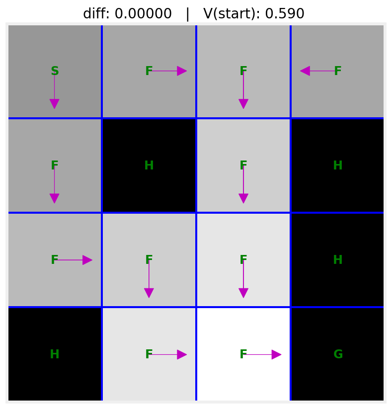

```python
state_values = {s: 0 for s in mdp.get_all_states()}

for i in range(10):
    clear_output(True)
    print("after iteration %i" % i)
    state_values, info = value_iteration(mdp, state_values, num_iter=1)
    draw_policy(mdp, state_values, info, i)
    plt.pause(0.5)
```

```
after iteration 29
iter    0   |   diff: 0.00000   |   V(start): 0.254
```

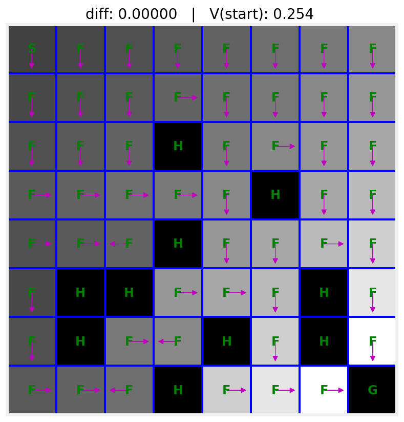

```python
mdp = FrozenLakeEnv(map_name='8x8', slip_chance=0.0)
state_values = {s: 0 for s in mdp.get_all_states()}

for i in range(30):
    clear_output(True)
    print("after iteration %i" % i)
    state_values, info = value_iteration(mdp, state_values, num_iter=1)
    draw_policy(mdp, state_values, info, i, True)
    plt.pause(0.5)
```

```python
make_gif('lake', 0.25, clean_when_done=True, reverse=False)
```

```python
%%html

<div style="display: flex; justify-content: row;">
    <img src='../data/lake.gif'>
</div>
```

[figure not shown]

```python
mdp = FrozenLakeEnv(slip_chance=0)
state_values, info = value_iteration(mdp)

total_rewards = []
for game_i in range(1000):
    s = mdp.reset()
    rewards = []
    for t in range(100):
        s, r, done, _ = mdp.step(get_optimal_action(mdp, state_values, s, gamma))
        rewards.append(r)
        if done:
            break
    total_rewards.append(np.sum(rewards))

print("average reward: ", np.mean(total_rewards))
```

```
iter    0   |   diff: 1.00000   |   V(start): 0.000
iter    1   |   diff: 0.90000   |   V(start): 0.000
iter    2   |   diff: 0.81000   |   V(start): 0.000
iter    3   |   diff: 0.72900   |   V(start): 0.000
iter    4   |   diff: 0.65610   |   V(start): 0.000
iter    5   |   diff: 0.59049   |   V(start): 0.590
iter    6   |   diff: 0.00000   |   V(start): 0.590
average reward:  1.0
```

```python
# Measure agent's average reward
mdp = FrozenLakeEnv(slip_chance=0.1)
state_values, info = value_iteration(mdp)

total_rewards = []
for game_i in range(1000):
    s = mdp.reset()
    rewards = []
    for t in range(100):
        s, r, done, _ = mdp.step(
            get_optimal_action(mdp, state_values, s, gamma))
        rewards.append(r)
        if done:
            break
    total_rewards.append(np.sum(rewards))

print("average reward: ", np.mean(total_rewards))
```

```
iter    0   |   diff: 0.90000   |   V(start): 0.000
iter    1   |   diff: 0.72900   |   V(start): 0.000
iter    2   |   diff: 0.62330   |   V(start): 0.000
iter    3   |   diff: 0.50487   |   V(start): 0.000
iter    4   |   diff: 0.40894   |   V(start): 0.000
iter    5   |   diff: 0.34868   |   V(start): 0.349
iter    6   |   diff: 0.06529   |   V(start): 0.410
iter    7   |   diff: 0.05832   |   V(start): 0.468
iter    8   |   diff: 0.01139   |   V(start): 0.480
iter    9   |   diff: 0.00764   |   V(start): 0.487
iter   10   |   diff: 0.00164   |   V(start): 0.489
iter   11   |   diff: 0.00094   |   V(start): 0.490
iter   12   |   diff: 0.00022   |   V(start): 0.490
iter   13   |   diff: 0.00011   |   V(start): 0.490
iter   14   |   diff: 0.00003   |   V(start): 0.490
iter   15   |   diff: 0.00001   |   V(start): 0.490
iter   16   |   diff: 0.00000   |   V(start): 0.490
average reward:  0.875
```

```python
# Measure agent's average reward
mdp = FrozenLakeEnv(slip_chance=0.25)
state_values, info = value_iteration(mdp)

total_rewards = []
for game_i in range(1000):
    s = mdp.reset()
    rewards = []
    for t in range(100):
        s, r, done, _ = mdp.step(
            get_optimal_action(mdp, state_values, s, gamma))
        rewards.append(r)
        if done:
            break
    total_rewards.append(np.sum(rewards))

print("average reward: ", np.mean(total_rewards))
```

```
iter    0   |   diff: 0.75000   |   V(start): 0.000
iter    1   |   diff: 0.50625   |   V(start): 0.000
iter    2   |   diff: 0.39867   |   V(start): 0.000
iter    3   |   diff: 0.26910   |   V(start): 0.000
iter    4   |   diff: 0.18164   |   V(start): 0.000
iter    5   |   diff: 0.14013   |   V(start): 0.140
iter    6   |   diff: 0.07028   |   V(start): 0.199
iter    7   |   diff: 0.06030   |   V(start): 0.260
iter    8   |   diff: 0.02594   |   V(start): 0.285
iter    9   |   diff: 0.01918   |   V(start): 0.305
iter   10   |   diff: 0.00858   |   V(start): 0.313
iter   11   |   diff: 0.00560   |   V(start): 0.319
iter   12   |   diff: 0.00260   |   V(start): 0.321
iter   13   |   diff: 0.00159   |   V(start): 0.323
iter   14   |   diff: 0.00076   |   V(start): 0.324
iter   15   |   diff: 0.00045   |   V(start): 0.324
iter   16   |   diff: 0.00022   |   V(start): 0.324
iter   17   |   diff: 0.00012   |   V(start): 0.325
iter   18   |   diff: 0.00006   |   V(start): 0.325
iter   19   |   diff: 0.00003   |   V(start): 0.325
iter   20   |   diff: 0.00002   |   V(start): 0.325
iter   21   |   diff: 0.00001   |   V(start): 0.325
average reward:  0.641
```

```python
# Measure agent's average reward
mdp = FrozenLakeEnv(slip_chance=0.2, map_name='8x8')
state_values, info = value_iteration(mdp)

total_rewards = []
for game_i in range(1000):
    s = mdp.reset()
    rewards = []
    for t in range(100):
        s, r, done, _ = mdp.step(
            get_optimal_action(mdp, state_values, s, gamma))
        rewards.append(r)
        if done:
            break
    total_rewards.append(np.sum(rewards))

print("average reward: ", np.mean(total_rewards))
```

```
iter    0   |   diff: 0.80000   |   V(start): 0.000
iter    1   |   diff: 0.57600   |   V(start): 0.000
iter    2   |   diff: 0.41472   |   V(start): 0.000
iter    3   |   diff: 0.29860   |   V(start): 0.000
iter    4   |   diff: 0.24186   |   V(start): 0.000
iter    5   |   diff: 0.19349   |   V(start): 0.000
iter    6   |   diff: 0.15325   |   V(start): 0.000
iter    7   |   diff: 0.12288   |   V(start): 0.000
iter    8   |   diff: 0.09930   |   V(start): 0.000
iter    9   |   diff: 0.08037   |   V(start): 0.000
iter   10   |   diff: 0.06426   |   V(start): 0.000
iter   11   |   diff: 0.05129   |   V(start): 0.000
iter   12   |   diff: 0.04330   |   V(start): 0.000
iter   13   |   diff: 0.03802   |   V(start): 0.033
iter   14   |   diff: 0.03332   |   V(start): 0.058
iter   15   |   diff: 0.02910   |   V(start): 0.087
iter   16   |   diff: 0.01855   |   V(start): 0.106
iter   17   |   diff: 0.01403   |   V(start): 0.120
iter   18   |   diff: 0.00810   |   V(start): 0.128
iter   19   |   diff: 0.00555   |   V(start): 0.133
iter   20   |   diff: 0.00321   |   V(start): 0.137
iter   21   |   diff: 0.00247   |   V(start): 0.138
iter   22   |   diff: 0.00147   |   V(start): 0.139
iter   23   |   diff: 0.00104   |   V(start): 0.140
iter   24   |   diff: 0.00058   |   V(start): 0.140
iter   25   |   diff: 0.00036   |   V(start): 0.141
iter   26   |   diff: 0.00024   |   V(start): 0.141
iter   27   |   diff: 0.00018   |   V(start): 0.141
iter   28   |   diff: 0.00012   |   V(start): 0.141
iter   29   |   diff: 0.00007   |   V(start): 0.141
iter   30   |   diff: 0.00004   |   V(start): 0.141
iter   31   |   diff: 0.00003   |   V(start): 0.141
iter   32   |   diff: 0.00001   |   V(start): 0.141
iter   33   |   diff: 0.00001   |   V(start): 0.141
average reward:  0.725
```

## Appendix: Types of RL Models

[figure not shown]

Figure is taken from: https://raw.githubusercontent.com/hollygrimm/markov-decision-processes/master/images/rl_algo_diagram.png

### Convert jupyter notebook into the html file with in a given format

```python
notebook_file = r"RL1_Markov_Decision_Processes.ipynb"
html_converter(notebook_file)
```